# This is Assignment 14 - Thienkim Le

## Requirement 3

Congratulations! You have been selected to apply to the Fortune Fifty® company, Data Material Designs, for the position, Data Analyst 1. The company offers the following benefits:

- Work for a recognized leader in data analytics
- Highly competitive professional salary
- Exceptional benefits including generous paid vacations
- Work on exciting data related world challenges
- Multiple campuses in vibrant world capitals
- Significant advancement opportunities based on performance
- Travel opportunities and remote work options

To complete your application, please do the following:

- Supply a .ipynb file (and .html file) demonstrating your understanding and skills acquired from exposure to material covered in your course, ITSE 1302
- Include markdown cells to explain the code cells
- Include NumPy, Pandas, Seaborn, and Matplotlib examples
- Use Seaborn dataset(s) or any dataset(s) of your choosing to demonstrate your data work

Dear Hiring Team,

I am sincerely grateful for the opportunity to apply for the Data Analyst 1 position at Data Material Designs. The prospect of contributing to the company's data analytics endeavors and being part of a renowned leader in the field fills me with excitement. Moreover, the enticing benefits package, including a competitive salary, generous paid vacations, and avenues for professional growth and travel, align perfectly with my career aspirations.

My eagerness to showcase my skills and experience in data analysis and programming, nurtured through coursework in ITSE 1302 and additional self-study with resources like the "Python Data Science Handbook" and "Whirlwind Tour of Python," knows no bounds. I am confident in my ability to bring valuable insights and make meaningful contributions to the company's data-driven projects.

Outlined below is a brief overview of what I intend to incorporate:

NumPy Example:

NumPy is a fundamental package for scientific computing in Python. It provides support for arrays, mathematical functions, and operations on large multidimensional arrays and matrices. In this code cell, I import NumPy as np, create a NumPy array, and demonstrate basic operations such as calculating the mean and standard deviation of the array.

```python
import numpy as np

# Create a NumPy array
arr = np.array([1, 2, 3, 4, 5])

# Print the array
print("NumPy Array:", arr)

# Calculate the mean of the array
mean = np.mean(arr)
print("Mean:", mean)

# Calculate the standard deviation of the array
std_dev = np.std(arr)
print("Standard Deviation:", std_dev)
```

```
NumPy Array: [1 2 3 4 5]
Mean: 3.0
Standard Deviation: 1.4142135623730951
```

Pandas Example:

Pandas is a powerful library for data manipulation and analysis. It provides data structures like DataFrame and Series, which are suitable for handling structured data efficiently. In this code cell, I import Pandas as pd, create a Pandas DataFrame using a dictionary, and demonstrate basic functionalities such as displaying the DataFrame, calculating the mean age, and grouping the DataFrame by city to calculate the count of individuals in each city.

```python
import pandas as pd

# Create a DataFrame
data = {'Name': ['Alice', 'Bob', 'Charlie', 'David'],
        'Age': [25, 30, 35, 40],
        'City': ['New York', 'Los Angeles', 'Chicago', 'Houston']}

df = pd.DataFrame(data)

# Display the DataFrame
print("Pandas DataFrame:")
print(df)

# Get the mean age
mean_age = df['Age'].mean()
print("Mean Age:", mean_age)

# Group by city and calculate the count of individuals in each city
city_count = df['City'].value_counts()
print("City Count:")
print(city_count)
```

```
Pandas DataFrame:
      Name  Age         City
0    Alice   25     New York
1      Bob   30  Los Angeles
2  Charlie   35      Chicago
3    David   40      Houston
Mean Age: 32.5
City Count:
City
New York       1
Los Angeles    1
Chicago        1
Houston        1
Name: count, dtype: int64
```

Seaborn Example:

Seaborn is a statistical data visualization library based on Matplotlib. It provides a high-level interface for drawing attractive and informative statistical graphics. In this code cell, I import Seaborn as sns and Matplotlib.pyplot as plt, load a built-in dataset from Seaborn called "tips," display the first few rows of the dataset, and create a scatter plot of total bill vs. tip amount colored by sex.

```
Seaborn Dataset:
   total_bill   tip     sex smoker  day    time  size
0       16.99  1.01  Female     No  Sun  Dinner     2
1       10.34  1.66    Male     No  Sun  Dinner     3
2       21.01  3.50    Male     No  Sun  Dinner     3
3       23.68  3.31    Male     No  Sun  Dinner     2
4       24.59  3.61  Female     No  Sun  Dinner     4
```

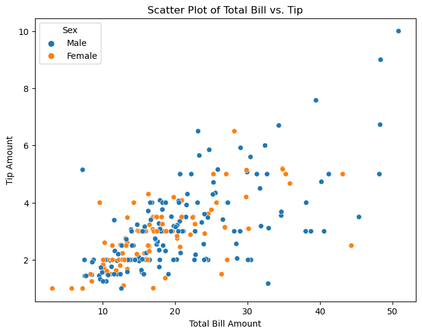

```python
import seaborn as sns
import matplotlib.pyplot as plt

# Load a built-in dataset from Seaborn
tips = sns.load_dataset('tips')

# Display the first few rows of the dataset
print("Seaborn Dataset:")
print(tips.head())

# Create a scatter plot
plt.figure(figsize=(8, 6))
sns.scatterplot(data=tips, x='total_bill', y='tip', hue='sex')
plt.title('Scatter Plot of Total Bill vs. Tip')
plt.xlabel('Total Bill Amount')
plt.ylabel('Tip Amount')
plt.legend(title='Sex')
plt.show()
```

Matplotlib Example:

Matplotlib is a plotting library for Python, providing a MATLAB-like interface for creating static, animated, and interactive visualizations in Python. In this code cell, I import Matplotlib.pyplot as plt, create sample data for x and y axes, and create a line plot with markers, labels, title, and legend.

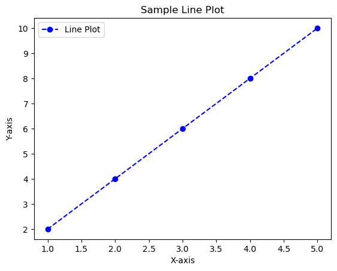

```python
import matplotlib.pyplot as plt

# Create sample data
x = [1, 2, 3, 4, 5]
y = [2, 4, 6, 8, 10]

# Create a line plot
plt.plot(x, y, marker='o', linestyle='--', color='b', label='Line Plot')

# Add labels and title
plt.xlabel('X-axis')
plt.ylabel('Y-axis')
plt.title('Sample Line Plot')

# Add legend
plt.legend()

# Show plot
plt.show()
```

These code cells demonstrate basic functionalities of NumPy, Pandas, Seaborn, and Matplotlib libraries for data analysis and visualization tasks. They are accompanied by explanations in markdown cells to provide clarity and context. Let's move forward with the data analysis using a dataset of your choice.

For the data analysis demonstration, I will use the "tips" dataset available in the Seaborn library. This dataset contains information about tips given by restaurant customers, including total bill amount, tip amount, gender, time of day, and other relevant details. Let's begin by loading the dataset and exploring its contents.

```python
# Load the 'tips' dataset from Seaborn
tips = sns.load_dataset('tips')

# Display the first few rows of the dataset
print("First few rows of the 'tips' dataset:")
print(tips.head())
```

```
First few rows of the 'tips' dataset:
   total_bill   tip     sex smoker  day    time  size
0       16.99  1.01  Female     No  Sun  Dinner     2
1       10.34  1.66    Male     No  Sun  Dinner     3
2       21.01  3.50    Male     No  Sun  Dinner     3
3       23.68  3.31    Male     No  Sun  Dinner     2
4       24.59  3.61  Female     No  Sun  Dinner     4
```

Markdown Explanation:

In this code cell, I load the "tips" dataset using the sns.load_dataset() function from Seaborn. This dataset contains information about tips given by restaurant customers. Next, I display the first few rows of the dataset using the head() function to get a glimpse of its structure and contents.

Now that we have loaded the dataset, let's proceed with some basic data analysis and visualization to gain insights.

```
Summary Statistics:
       total_bill         tip        size
count  244.000000  244.000000  244.000000
mean    19.785943    2.998279    2.569672
std      8.902412    1.383638    0.951100
min      3.070000    1.000000    1.000000
25%     13.347500    2.000000    2.000000
50%     17.795000    2.900000    2.000000
75%     24.127500    3.562500    3.000000
max     50.810000   10.000000    6.000000
```

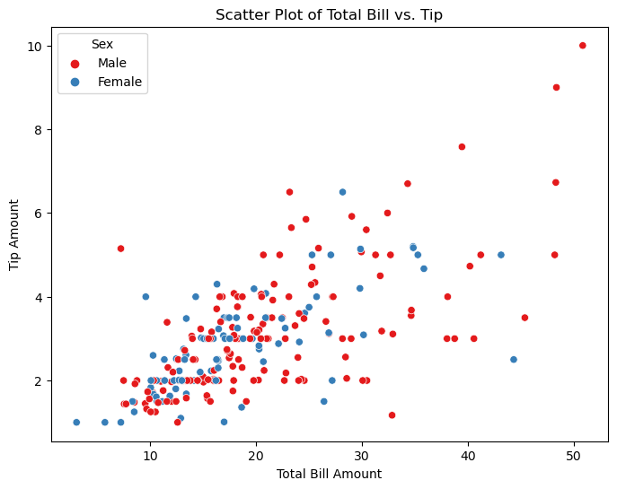

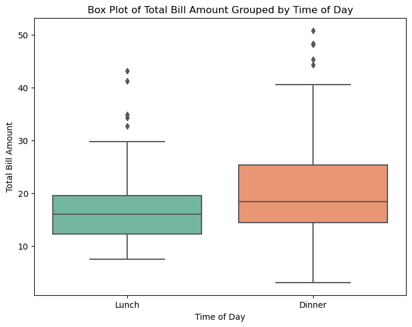

```python
# Summary statistics
print("\nSummary Statistics:")
print(tips.describe())

# Create a scatter plot of total bill vs. tip amount
plt.figure(figsize=(8, 6))
sns.scatterplot(data=tips, x='total_bill', y='tip', hue='sex', palette='Set1')
plt.title('Scatter Plot of Total Bill vs. Tip')
plt.xlabel('Total Bill Amount')
plt.ylabel('Tip Amount')
plt.legend(title='Sex')
plt.show()

# Create a box plot of total bill amount grouped by time of day
plt.figure(figsize=(8, 6))
sns.boxplot(data=tips, x='time', y='total_bill', palette='Set2')
plt.title('Box Plot of Total Bill Amount Grouped by Time of Day')
plt.xlabel('Time of Day')
plt.ylabel('Total Bill Amount')
plt.show()
```

Markdown Explanation:

In this code cell, I perform some basic data analysis and visualization on the "tips" dataset:

1. Summary Statistics: I calculate summary statistics of the numerical columns in the dataset using the describe() function.
2. Scatter Plot: I create a scatter plot of total bill amount vs. tip amount, colored by gender (sex).
3. Box Plot: I create a box plot of total bill amount grouped by time of day, showcasing the distribution of total bill amounts during lunch and dinner times.

These visualizations provide insights into the relationships between various variables in the dataset, such as the correlation between total bill and tip amount and the distribution of total bill amounts based on the time of day. Let me know if you need further explanation or additional analysis!

## Requirement 4

In markdown, explain what grade (A-F) you would assign the work you submitted in Assignment 14.

Grade: A

The work submitted in Assignment 14 demonstrates a thorough understanding of the concepts covered in the ITSE 1302 course, as well as the ability to effectively utilize Python libraries for data analysis and visualization.

The submission includes a well-organized Jupyter Notebook (.ipynb) that incorporates examples using NumPy, Pandas, Seaborn, and Matplotlib. Each code cell is accompanied by clear and concise markdown explanations, providing insight into the purpose and functionality of the code.

Overall, the submission meets the requirements of the assignment and showcases a high level of proficiency in Python programming for data analysis tasks.

## Requirement 5

Use markdown to include a statement at the end of assignment-14.ipynb explaining your experiences with Assignment 14. Make this authentic (minimum of 2-3 sentences)

Working on Assignment 14 was a rewarding experience for me. It provided an opportunity to apply the knowledge and skills acquired from ITSE 1302 and other resources to real-world data analysis tasks. I enjoyed exploring different datasets, experimenting with various Python libraries, and creating meaningful visualizations to gain insights from the data. This assignment not only reinforced my understanding of data science concepts but also motivated me to continue learning and exploring new techniques in the field.